# Assignment 2

## 2.2 Grammar of graphics: geoms

1. We would use geom_line() to draw a line chart, geom_area() for area chart, geom_histogram() for histogram and geom_boxplot() for boxplot.
2. No, they would not look different. Both programs give the same instruction you can write mapping in ggplot or geom_point/geom_smooth it doesnt’t matter.

```r
ggplot(data = mpg, mapping = aes(x = displ, y = hwy)) +
geom_point() +
geom_smooth()
ggplot() +
geom_point(data = mpg, mapping = aes(x = displ, y = hwy)) +
geom_smooth(data = mpg, mapping = aes(x = displ, y = hwy))
```

3. The se argument is for the standard error in the geom_smooth line. It creates a highlighted area next to smooth line to show standard error. The default value passed to se is TRUE. You can switch off se by mentioning se=FALSE in argument.

```r
ggplot(data = mpg, mapping = aes(x = displ, y = hwy)) +
geom_point() +
geom_smooth()
```

4. Reproduced the graphs.

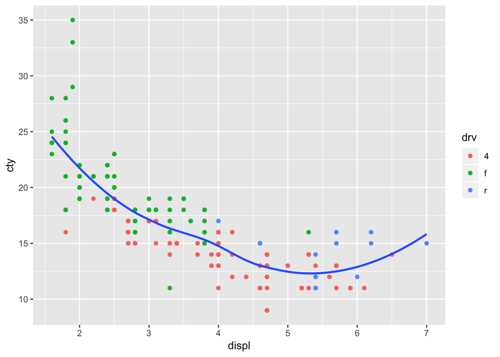

```r
library(ggplot2)
ggplot(data = mpg, mapping = aes(x = displ, y = cty))+
geom_point(aes(color = drv)) +
geom_smooth(se=FALSE)
```

5.Improving the graph by:

• make line black • make the x- and y-axes labels more informative using + labs() • use an informative title to capture the headline finding of your analysis • remove the legend (google might be helpful to learn how)

I feel changes were helpful especially labelling as well as changing the line color to black. Title also brought a life to the graph as it become so easier what graph is about and what is our motive.

I feel removing the legend was not helpful as we do not know what do colors dot imply.

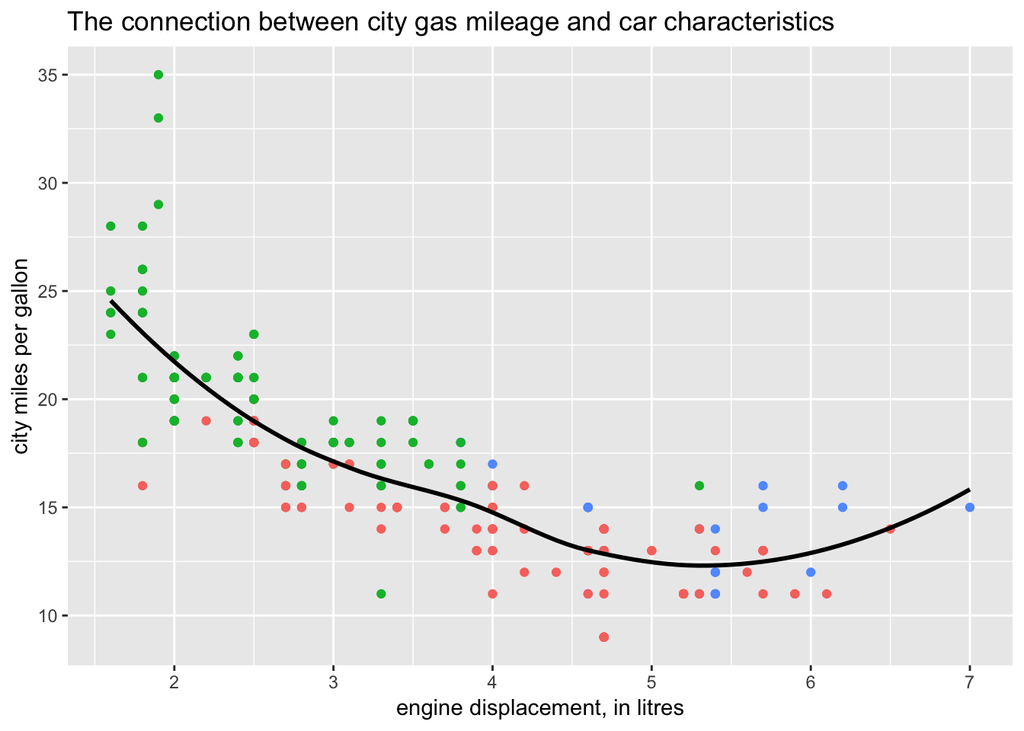

```r
ggplot(data = mpg, mapping = aes(x = displ, y = cty))+
labs(title = "The connection between city gas mileage and car characteristics ",x = "engine displacement, in litres", y= "city miles per gallon") +
geom_point(show.legend = FALSE, aes(color = drv)) +
geom_smooth(se=FALSE, color= "black")
```

### 2.2.1 Grammar of graphics: Statistical transformations

1. geom_bar and geom_col construct bar charts. The difference is that geom_bar counts the frequency of the each group and then constructs y axis of count according to the x frequency in data. geom_col doesn’t do this unless instructed in argument. It requires x as well as y variable to plot the values of the x variable against the y variable you give. Bar height depends on y variable.
2. Replaced geom with stat_count to construct the same graph.

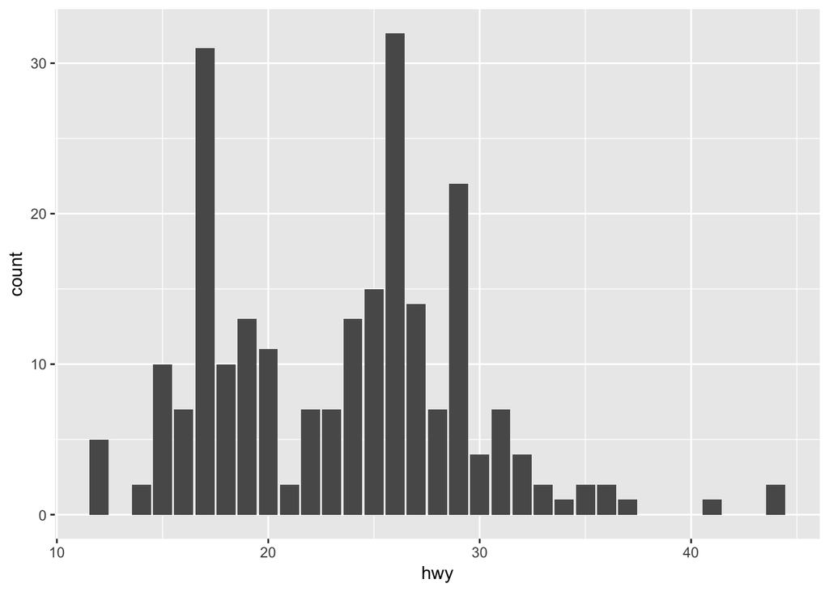

```r
ggplot(data=mpg, aes(x=hwy)) + geom_bar()
```

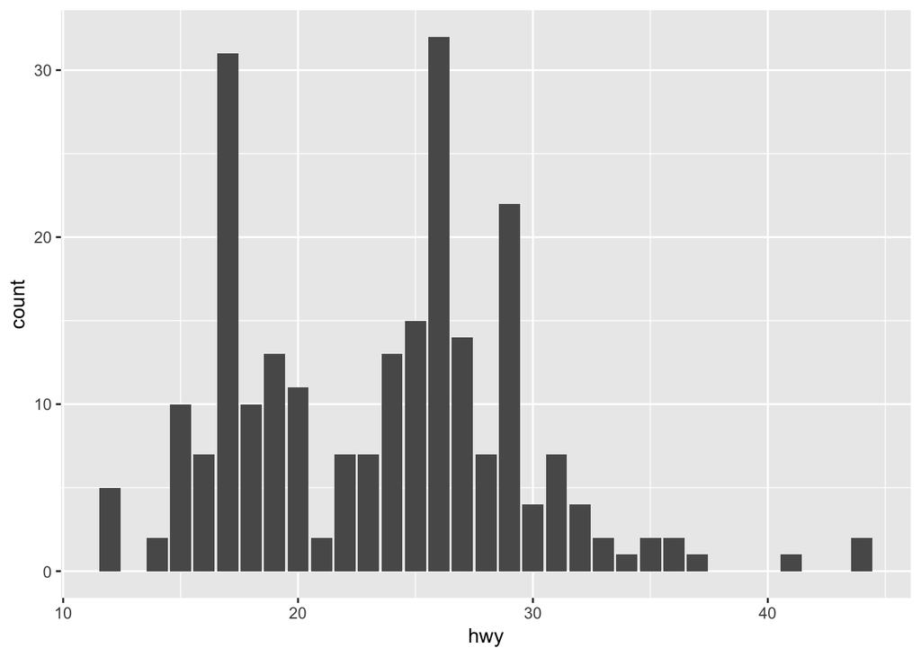

```r
ggplot(data=mpg, aes(x=hwy)) + stat_count()
```

3.Computed variables by stat_smooth (R HELP) y predicted value ymin - lower pointwise confidence interval around the mean ymax - upper pointwise confidence interval around the mean se - standard error

There’s parameters such as method which determines which method is used to calculate the predictions and confidence interval, and some other arguments that are passed to that.(answer rstudio pub) These variables are displayed on the plot. Y is the line the predicted. ymin is the lowest value of y ymax is highest value of y se is standard error shown by highlighted area

4. There are many that come in pairs

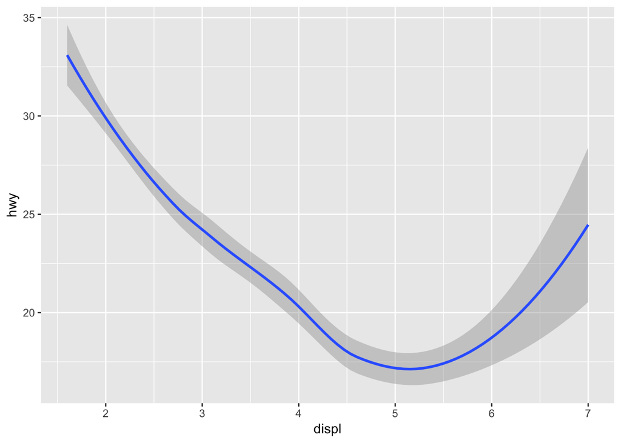

```r
ggplot(mpg, aes(x=displ, y=hwy)) + stat_smooth()
```

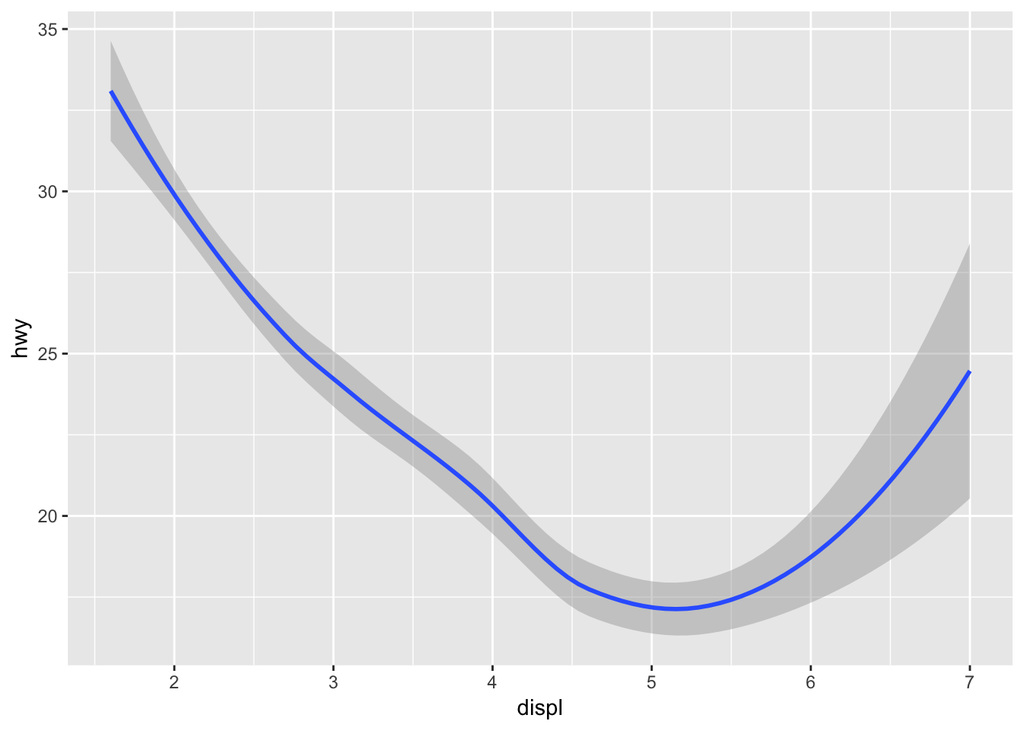

```r
#
ggplot(mpg, aes(x=displ, y=hwy)) + geom_smooth()
```

5. We needed to specify the group = 1 is a dummy variable to override the problem of geom_bar function checking fair in fair or ideal in ideal which will be 100%. This tells the function that it needs to group by cut

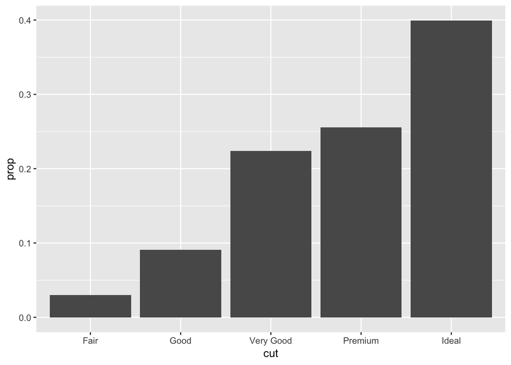

```r
ggplot(data = diamonds) +
geom_bar(mapping = aes(x = cut, y = ..prop.., group =1))
```

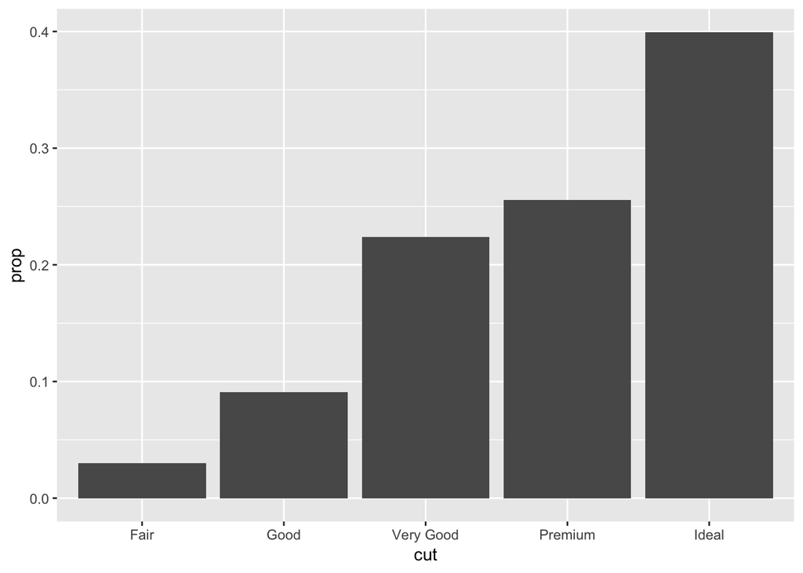

```r
ggplot(data = diamonds) +
geom_bar(mapping = aes(x = cut, fill = color, y = ..prop.., group=1))
```

## 2.3 grammar of graphics: Positional adjustments

1. Points are being overlapped here as they are small integers. In other words points are hiding each other. we can make transparent according to their overlapping by alpha as well as jitter points to avoid overplotting.

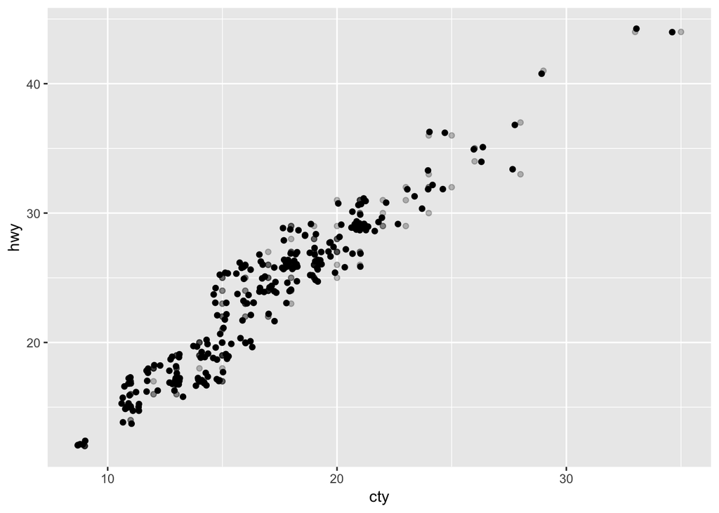

```r
ggplot(data = mpg, mapping = aes(x = cty, y = hwy)) +
geom_point(alpha =0.25)+
  geom_jitter()
```

2. width and height in geom_jitter() control the jittering. “Amount of vertical and horizontal jitter. The jitter is added in both positive and negative directions, so the total spread is twice the value specified here. If omitted, defaults to 40% of the resolution of the data: this means the jitter values will occupy 80% of the implied bins. Categorical data is aligned on the integers, so a width or height of 0.5 will spread the data so it’s not possible to see the distinction between the categories.” (R HELP)
3. geom_count is counting the observation and displaying them bigger if there is an overlapping. geom_jitter is making them visible but they are all of same size. " geom_jitter adds a small amount of random variation to the location of each point, and is a useful way of handling overplotting caused by discreteness in smaller datasets." (graphics from R4ds book)

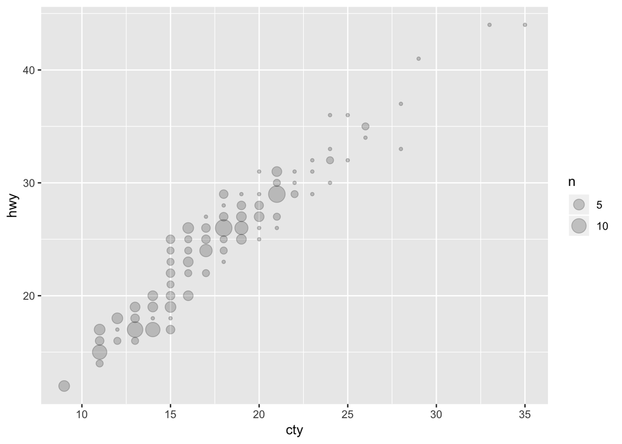

```r
ggplot(data = mpg, mapping = aes(x = cty, y = hwy)) +
geom_count(alpha=0.2)
```

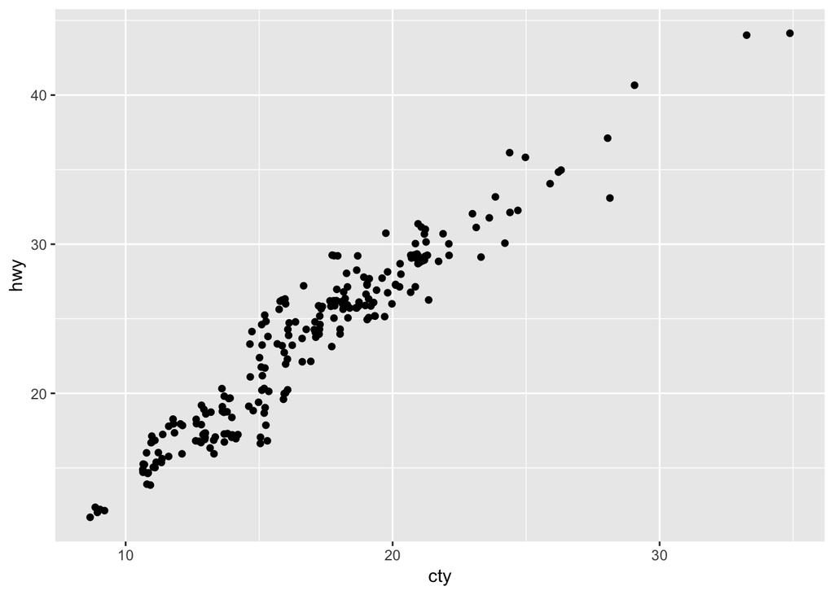

```r
ggplot(data = mpg, mapping = aes(x = cty, y = hwy)) +
geom_jitter()
```

4. The default position adjustment for geom_bar() is stack. You changed the position to dodge as below.

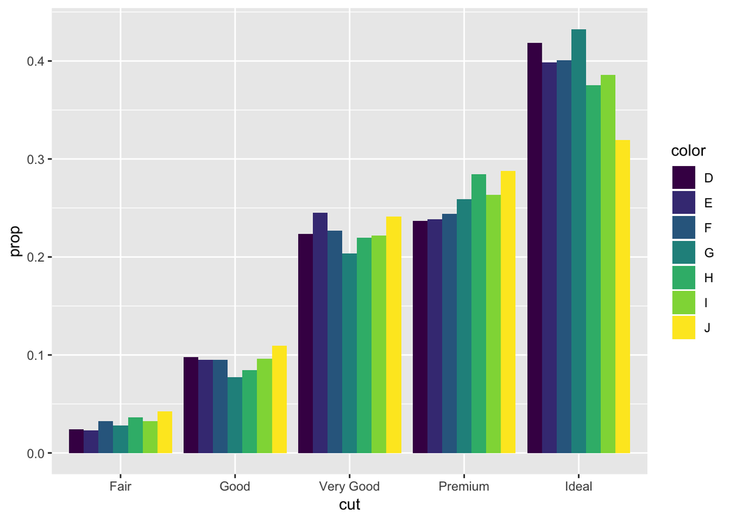

```r
library(ggplot2)
ggplot(data = diamonds) +
geom_bar(mapping = aes(x = cut, y=..prop.., fill = color, group =color),position = "dodge")
```

## 2.4 grammar of graphics: Coordinate systems

1. coord_flip() flips the coordinartes of the graph as tried below.

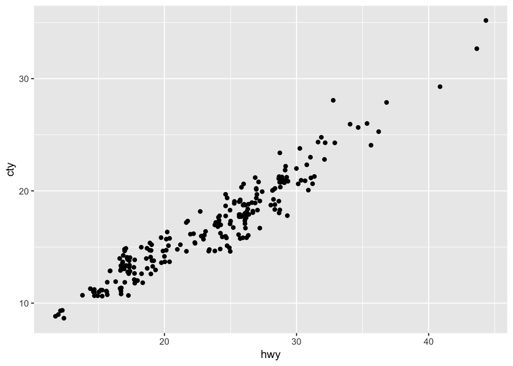

```r
ggplot(data = mpg, mapping = aes(x = cty, y = hwy)) +
geom_jitter() +
  coord_flip()
```

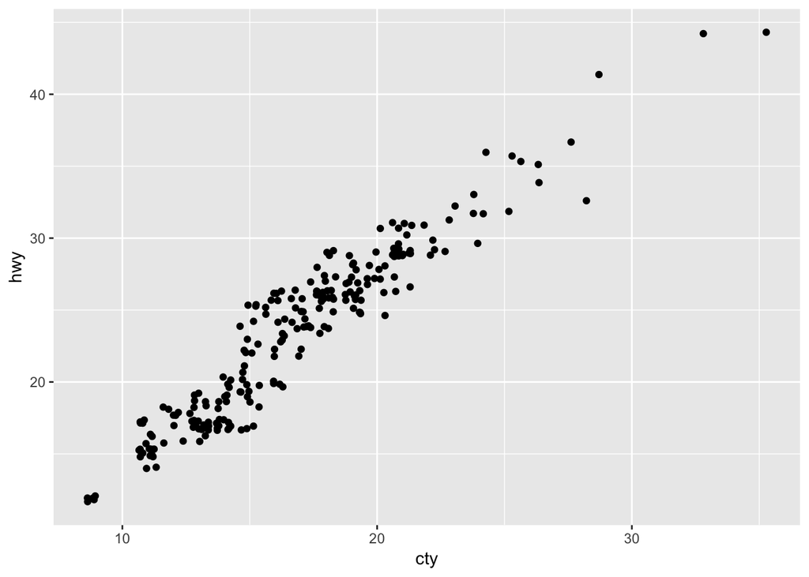

```r
ggplot(data = mpg, mapping = aes(x = cty, y = hwy)) +
geom_jitter()
```

2. cty and hwy have a linear relationship. If the cars provide good hwy average, they provide good cty average as well. The cars that give poor average in cty, also gives poor average on hwy. Using coord_fixed() was helpful when graph was zoomed in/out on the console, it was not distorted. x and y coordinates were on equal intervals to make comparison easier.

Using geom_abline() constructs a line with a slope of 1 or 45 degrees to help us see the regression.

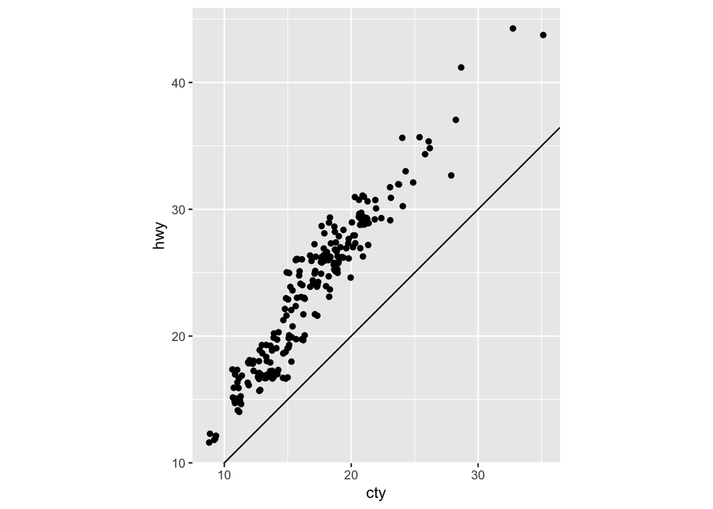

```r
library(ggplot2)
ggplot(data = mpg, mapping = aes(x = cty, y = hwy)) +
geom_jitter() +
  coord_fixed()+
  geom_abline()
```

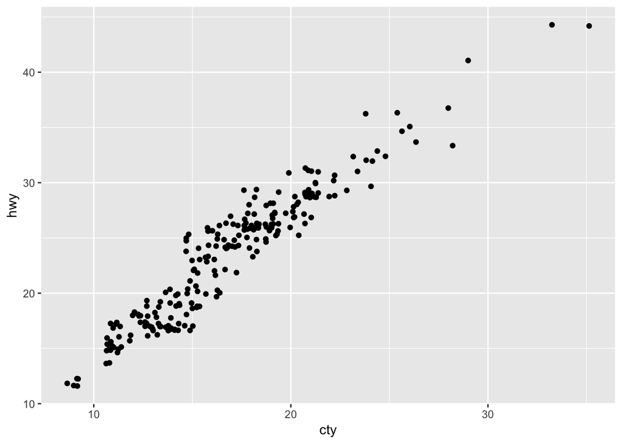

```r
ggplot(data = mpg, mapping = aes(x = cty, y = hwy)) +
geom_jitter()
```

## 2.5 Transformations: Filter rows with filter()

1. Use nycflights13 library to solve using filter a.Had an arrival delay of three or more hours

```r
library(nycflights13)
# 1. had an arrival delay of 3 hours or more
flights <- nycflights13::flights
filter(flights, arr_delay>=180)
```

```
## # A tibble: 3,897 x 19
##     year month   day dep_time sched_dep_time dep_delay arr_time
##    <int> <int> <int>    <int>          <int>     <dbl>    <int>
##  1  2013     1     1      848           1835       853     1001
##  2  2013     1     1     1815           1325       290     2120
##  3  2013     1     1     1842           1422       260     1958
##  4  2013     1     1     2006           1630       216     2230
##  5  2013     1     1     2115           1700       255     2330
##  6  2013     1     1     2205           1720       285       46
##  7  2013     1     1     2312           2000       192       21
##  8  2013     1     1     2343           1724       379      314
##  9  2013     1     2     1244            900       224     1431
## 10  2013     1     2     1332            904       268     1616
## # ... with 3,887 more rows, and 12 more variables: sched_arr_time <int>,
## #   arr_delay <dbl>, carrier <chr>, flight <int>, tailnum <chr>,
## #   origin <chr>, dest <chr>, air_time <dbl>, distance <dbl>, hour <dbl>,
## #   minute <dbl>, time_hour <dttm>
```

2. Flew to Houston (IAH or HOU)

```r
# 2.  Flew to Houston (IAH or HOU)
filter(flights, dest == "IAH"|dest == "HOU")
```

```
## # A tibble: 9,313 x 19
##     year month   day dep_time sched_dep_time dep_delay arr_time
##    <int> <int> <int>    <int>          <int>     <dbl>    <int>
##  1  2013     1     1      517            515         2      830
##  2  2013     1     1      533            529         4      850
##  3  2013     1     1      623            627        -4      933
##  4  2013     1     1      728            732        -4     1041
##  5  2013     1     1      739            739         0     1104
##  6  2013     1     1      908            908         0     1228
##  7  2013     1     1     1028           1026         2     1350
##  8  2013     1     1     1044           1045        -1     1352
##  9  2013     1     1     1114            900       134     1447
## 10  2013     1     1     1205           1200         5     1503
## # ... with 9,303 more rows, and 12 more variables: sched_arr_time <int>,
## #   arr_delay <dbl>, carrier <chr>, flight <int>, tailnum <chr>,
## #   origin <chr>, dest <chr>, air_time <dbl>, distance <dbl>, hour <dbl>,
## #   minute <dbl>, time_hour <dttm>
```

3. Were operated by United, American, or Southwest

```r
#3. Were operated by United, American, or Southwest
filter(flights, carrier  %in%  c("UA", "AA", "WN"))
```

```
## # A tibble: 103,669 x 19
##     year month   day dep_time sched_dep_time dep_delay arr_time
##    <int> <int> <int>    <int>          <int>     <dbl>    <int>
##  1  2013     1     1      517            515         2      830
##  2  2013     1     1      533            529         4      850
##  3  2013     1     1      542            540         2      923
##  4  2013     1     1      554            558        -4      740
##  5  2013     1     1      558            600        -2      753
##  6  2013     1     1      558            600        -2      924
##  7  2013     1     1      558            600        -2      923
##  8  2013     1     1      559            600        -1      941
##  9  2013     1     1      559            600        -1      854
## 10  2013     1     1      606            610        -4      858
## # ... with 103,659 more rows, and 12 more variables: sched_arr_time <int>,
## #   arr_delay <dbl>, carrier <chr>, flight <int>, tailnum <chr>,
## #   origin <chr>, dest <chr>, air_time <dbl>, distance <dbl>, hour <dbl>,
## #   minute <dbl>, time_hour <dttm>
```

4. Departed in spring (March, April, and June)

```r
# 4. Departed in spring (March, April, and June)
filter(flights, month %in% c(3, 4, 6))
```

```
## # A tibble: 85,407 x 19
##     year month   day dep_time sched_dep_time dep_delay arr_time
##    <int> <int> <int>    <int>          <int>     <dbl>    <int>
##  1  2013     3     1        4           2159       125      318
##  2  2013     3     1       50           2358        52      526
##  3  2013     3     1      117           2245       152      223
##  4  2013     3     1      454            500        -6      633
##  5  2013     3     1      505            515       -10      746
##  6  2013     3     1      521            530        -9      813
##  7  2013     3     1      537            540        -3      856
##  8  2013     3     1      541            545        -4     1014
##  9  2013     3     1      549            600       -11      639
## 10  2013     3     1      550            600       -10      747
## # ... with 85,397 more rows, and 12 more variables: sched_arr_time <int>,
## #   arr_delay <dbl>, carrier <chr>, flight <int>, tailnum <chr>,
## #   origin <chr>, dest <chr>, air_time <dbl>, distance <dbl>, hour <dbl>,
## #   minute <dbl>, time_hour <dttm>
```

e.Arrived more than two hours late, but didn’t leave late

```r
#5.  Arrived more than two hours late, but didn’t leave late
filter(flights, arr_delay >120, dep_delay <=0)
```

```
## # A tibble: 29 x 19
##     year month   day dep_time sched_dep_time dep_delay arr_time
##    <int> <int> <int>    <int>          <int>     <dbl>    <int>
##  1  2013     1    27     1419           1420        -1     1754
##  2  2013    10     7     1350           1350         0     1736
##  3  2013    10     7     1357           1359        -2     1858
##  4  2013    10    16      657            700        -3     1258
##  5  2013    11     1      658            700        -2     1329
##  6  2013     3    18     1844           1847        -3       39
##  7  2013     4    17     1635           1640        -5     2049
##  8  2013     4    18      558            600        -2     1149
##  9  2013     4    18      655            700        -5     1213
## 10  2013     5    22     1827           1830        -3     2217
## # ... with 19 more rows, and 12 more variables: sched_arr_time <int>,
## #   arr_delay <dbl>, carrier <chr>, flight <int>, tailnum <chr>,
## #   origin <chr>, dest <chr>, air_time <dbl>, distance <dbl>, hour <dbl>,
## #   minute <dbl>, time_hour <dttm>
```

6. Were delayed by at least an hour, but made up over 30 minutes in flight

```r
#6.Were delayed by at least an hour, but made up over 30 minutes in flight
filter(flights, dep_delay >=60, dep_delay - arr_delay > 30)
```

```
## # A tibble: 1,844 x 19
##     year month   day dep_time sched_dep_time dep_delay arr_time
##    <int> <int> <int>    <int>          <int>     <dbl>    <int>
##  1  2013     1     1     2205           1720       285       46
##  2  2013     1     1     2326           2130       116      131
##  3  2013     1     3     1503           1221       162     1803
##  4  2013     1     3     1839           1700        99     2056
##  5  2013     1     3     1850           1745        65     2148
##  6  2013     1     3     1941           1759       102     2246
##  7  2013     1     3     1950           1845        65     2228
##  8  2013     1     3     2015           1915        60     2135
##  9  2013     1     3     2257           2000       177       45
## 10  2013     1     4     1917           1700       137     2135
## # ... with 1,834 more rows, and 12 more variables: sched_arr_time <int>,
## #   arr_delay <dbl>, carrier <chr>, flight <int>, tailnum <chr>,
## #   origin <chr>, dest <chr>, air_time <dbl>, distance <dbl>, hour <dbl>,
## #   minute <dbl>, time_hour <dttm>
```

1g. Departed between midnight and 5am (inclusive)

```r
#7. Departed between midnight and 5am (inclusive)
filter(flights, dep_time <=0500 | dep_time ==2400)
```

```
## # A tibble: 1,516 x 19
##     year month   day dep_time sched_dep_time dep_delay arr_time
##    <int> <int> <int>    <int>          <int>     <dbl>    <int>
##  1  2013     1     2       42           2359        43      518
##  2  2013     1     2      126           2250       156      233
##  3  2013     1     2      458            500        -2      703
##  4  2013     1     3       32           2359        33      504
##  5  2013     1     3       50           2145       185      203
##  6  2013     1     3      235           2359       156      700
##  7  2013     1     3      458            500        -2      650
##  8  2013     1     4       25           2359        26      505
##  9  2013     1     4      106           2245       141      201
## 10  2013     1     4      456            500        -4      631
## # ... with 1,506 more rows, and 12 more variables: sched_arr_time <int>,
## #   arr_delay <dbl>, carrier <chr>, flight <int>, tailnum <chr>,
## #   origin <chr>, dest <chr>, air_time <dbl>, distance <dbl>, hour <dbl>,
## #   minute <dbl>, time_hour <dttm>
```

2. In the graph you created below, there is one green point that has very low gas mileage. That car is dodge caravan 2wd

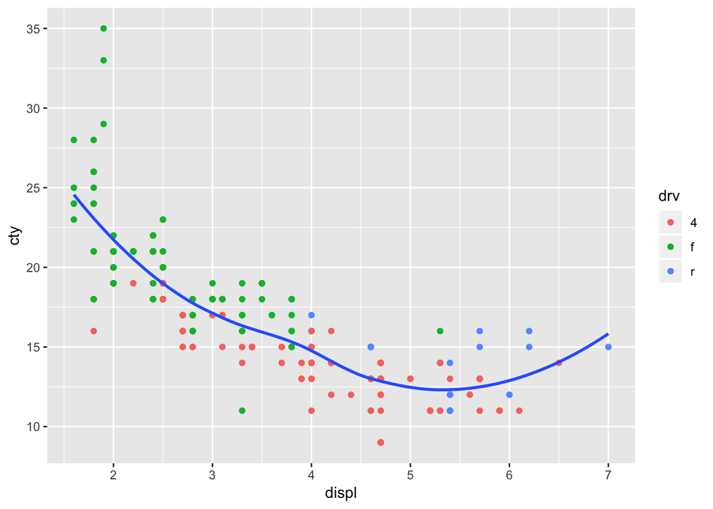

```r
ggplot(data = mpg, mapping = aes(x = displ, y = cty)) +
  geom_point(aes(color = drv))+
geom_smooth(se = FALSE)
```

```r
filter(head(mpg[order(mpg$cty, decreasing=FALSE), ], 10), drv=="f")
```

```
## # A tibble: 1 x 11
##   manufacturer model displ  year   cyl trans drv     cty   hwy fl    class
##   <chr>        <chr> <dbl> <int> <int> <chr> <chr> <int> <int> <chr> <chr>
## 1 dodge        cara…   3.3  2008     6 auto… f        11    17 e     mini…
```

3.It is wrong because you need to use is.na to look for NA values. There is no NA entered there but there is null value.

```r
filter(flights, is.na(arr_time))
```

```
## # A tibble: 8,713 x 19
##     year month   day dep_time sched_dep_time dep_delay arr_time
##    <int> <int> <int>    <int>          <int>     <dbl>    <int>
##  1  2013     1     1     2016           1930        46       NA
##  2  2013     1     1       NA           1630        NA       NA
##  3  2013     1     1       NA           1935        NA       NA
##  4  2013     1     1       NA           1500        NA       NA
##  5  2013     1     1       NA            600        NA       NA
##  6  2013     1     2     2041           2045        -4       NA
##  7  2013     1     2     2145           2129        16       NA
##  8  2013     1     2       NA           1540        NA       NA
##  9  2013     1     2       NA           1620        NA       NA
## 10  2013     1     2       NA           1355        NA       NA
## # ... with 8,703 more rows, and 12 more variables: sched_arr_time <int>,
## #   arr_delay <dbl>, carrier <chr>, flight <int>, tailnum <chr>,
## #   origin <chr>, dest <chr>, air_time <dbl>, distance <dbl>, hour <dbl>,
## #   minute <dbl>, time_hour <dttm>
```

4. 8255 flights have missing dep_time. All other variables that have missing values is displayed. They represent they have no values in them.

```r
# if dep_time has any na values
sum(is.na(flights$dep_time))
```

```
## [1] 8255
```

```r
# checking for other missing
flights%>%
filter(is.na(dep_time)) %>%
map(~sum(is.na(.)))
```

```
## $year
## [1] 0
##
## $month
## [1] 0
##
## $day
## [1] 0
##
## $dep_time
## [1] 8255
##
## $sched_dep_time
## [1] 0
##
## $dep_delay
## [1] 8255
##
## $arr_time
## [1] 8255
##
## $sched_arr_time
## [1] 0
##
## $arr_delay
## [1] 8255
##
## $carrier
## [1] 0
##
## $flight
## [1] 0
##
## $tailnum
## [1] 2512
##
## $origin
## [1] 0
##
## $dest
## [1] 0
##
## $air_time
## [1] 8255
##
## $distance
## [1] 0
##
## $hour
## [1] 0
##
## $minute
## [1] 0
##
## $time_hour
## [1] 0
```

5. Only the arr_time =1800 values will be displayed because of the condition you have specified.

6.NA | True evaluate to TRUE as in boolean will pick up true as the condition is or.

7.FALSE & NA evaluate to FALSE as “&” operators wants both the conditions .

## 2.6 Transformations: Sort columns with arrange()

1. Arranged such that NA values in starting.

```r
#checked for dep time
flights %>%
arrange(desc(is.na(dep_time)))
```

```
## # A tibble: 336,776 x 19
##     year month   day dep_time sched_dep_time dep_delay arr_time
##    <int> <int> <int>    <int>          <int>     <dbl>    <int>
##  1  2013     1     1       NA           1630        NA       NA
##  2  2013     1     1       NA           1935        NA       NA
##  3  2013     1     1       NA           1500        NA       NA
##  4  2013     1     1       NA            600        NA       NA
##  5  2013     1     2       NA           1540        NA       NA
##  6  2013     1     2       NA           1620        NA       NA
##  7  2013     1     2       NA           1355        NA       NA
##  8  2013     1     2       NA           1420        NA       NA
##  9  2013     1     2       NA           1321        NA       NA
## 10  2013     1     2       NA           1545        NA       NA
## # ... with 336,766 more rows, and 12 more variables: sched_arr_time <int>,
## #   arr_delay <dbl>, carrier <chr>, flight <int>, tailnum <chr>,
## #   origin <chr>, dest <chr>, air_time <dbl>, distance <dbl>, hour <dbl>,
## #   minute <dbl>, time_hour <dttm>
```

2. Sort flights to find the most delayed flights by arrival time

```r
flights %>%
arrange(desc(arr_delay))
```

```
## # A tibble: 336,776 x 19
##     year month   day dep_time sched_dep_time dep_delay arr_time
##    <int> <int> <int>    <int>          <int>     <dbl>    <int>
##  1  2013     1     9      641            900      1301     1242
##  2  2013     6    15     1432           1935      1137     1607
##  3  2013     1    10     1121           1635      1126     1239
##  4  2013     9    20     1139           1845      1014     1457
##  5  2013     7    22      845           1600      1005     1044
##  6  2013     4    10     1100           1900       960     1342
##  7  2013     3    17     2321            810       911      135
##  8  2013     7    22     2257            759       898      121
##  9  2013    12     5      756           1700       896     1058
## 10  2013     5     3     1133           2055       878     1250
## # ... with 336,766 more rows, and 12 more variables: sched_arr_time <int>,
## #   arr_delay <dbl>, carrier <chr>, flight <int>, tailnum <chr>,
## #   origin <chr>, dest <chr>, air_time <dbl>, distance <dbl>, hour <dbl>,
## #   minute <dbl>, time_hour <dttm>
```

3. Find the flights that left earliest relative to their scheduled departure.

```r
flights %>%
arrange(dep_delay)
```

```
## # A tibble: 336,776 x 19
##     year month   day dep_time sched_dep_time dep_delay arr_time
##    <int> <int> <int>    <int>          <int>     <dbl>    <int>
##  1  2013    12     7     2040           2123       -43       40
##  2  2013     2     3     2022           2055       -33     2240
##  3  2013    11    10     1408           1440       -32     1549
##  4  2013     1    11     1900           1930       -30     2233
##  5  2013     1    29     1703           1730       -27     1947
##  6  2013     8     9      729            755       -26     1002
##  7  2013    10    23     1907           1932       -25     2143
##  8  2013     3    30     2030           2055       -25     2213
##  9  2013     3     2     1431           1455       -24     1601
## 10  2013     5     5      934            958       -24     1225
## # ... with 336,766 more rows, and 12 more variables: sched_arr_time <int>,
## #   arr_delay <dbl>, carrier <chr>, flight <int>, tailnum <chr>,
## #   origin <chr>, dest <chr>, air_time <dbl>, distance <dbl>, hour <dbl>,
## #   minute <dbl>, time_hour <dttm>
```

## 2.7 Transformations: Select columns with select()

1. Brainstorm as many ways as possible to select dep_time, dep_delay, arr_time, and arr_delay from flights

```r
flights %>%
select(dep_time, dep_delay, arr_time, arr_delay)
```

```
## # A tibble: 336,776 x 4
##    dep_time dep_delay arr_time arr_delay
##       <int>     <dbl>    <int>     <dbl>
##  1      517         2      830        11
##  2      533         4      850        20
##  3      542         2      923        33
##  4      544        -1     1004       -18
##  5      554        -6      812       -25
##  6      554        -4      740        12
##  7      555        -5      913        19
##  8      557        -3      709       -14
##  9      557        -3      838        -8
## 10      558        -2      753         8
## # ... with 336,766 more rows
```

```r
select(flights, c(dep_time, dep_delay, arr_time, arr_delay))
```

```
## # A tibble: 336,776 x 4
##    dep_time dep_delay arr_time arr_delay
##       <int>     <dbl>    <int>     <dbl>
##  1      517         2      830        11
##  2      533         4      850        20
##  3      542         2      923        33
##  4      544        -1     1004       -18
##  5      554        -6      812       -25
##  6      554        -4      740        12
##  7      555        -5      913        19
##  8      557        -3      709       -14
##  9      557        -3      838        -8
## 10      558        -2      753         8
## # ... with 336,766 more rows
```

```r
select(flights, dep_time, dep_delay, arr_time, arr_delay)
```

```
## # A tibble: 336,776 x 4
##    dep_time dep_delay arr_time arr_delay
##       <int>     <dbl>    <int>     <dbl>
##  1      517         2      830        11
##  2      533         4      850        20
##  3      542         2      923        33
##  4      544        -1     1004       -18
##  5      554        -6      812       -25
##  6      554        -4      740        12
##  7      555        -5      913        19
##  8      557        -3      709       -14
##  9      557        -3      838        -8
## 10      558        -2      753         8
## # ... with 336,766 more rows
```

2. It doesn’t make a difference, it selects only once.

```r
 select(flights, arr_time, arr_time)
```

```
## # A tibble: 336,776 x 1
##    arr_time
##       <int>
##  1      830
##  2      850
##  3      923
##  4     1004
##  5      812
##  6      740
##  7      913
##  8      709
##  9      838
## 10      753
## # ... with 336,766 more rows
```

3. All the columns that had time in the column names were selected. Yes it surprises us as the TIME was also not case sensitive.

yes default is insensitive to case but we can add ignore.case = FALSE to make it case sensitive in contains.

```r
select(flights, contains("TIME"))
```

```
## # A tibble: 336,776 x 6
##    dep_time sched_dep_time arr_time sched_arr_time air_time
##       <int>          <int>    <int>          <int>    <dbl>
##  1      517            515      830            819      227
##  2      533            529      850            830      227
##  3      542            540      923            850      160
##  4      544            545     1004           1022      183
##  5      554            600      812            837      116
##  6      554            558      740            728      150
##  7      555            600      913            854      158
##  8      557            600      709            723       53
##  9      557            600      838            846      140
## 10      558            600      753            745      138
## # ... with 336,766 more rows, and 1 more variable: time_hour <dttm>
```

```r
select(flights, contains("TIME", ignore.case = FALSE))
```

```
## # A tibble: 336,776 x 0
```

## 2.8 Transformations: Add new variables with mutate()

1. Converted them to minutes from the midnight.  
   Hours multiplied by 60 plus minutes for both the columns.

```r
mutate(flights,dep_time = ((dep_time %% 100) + (dep_time %/% 100)*60),sched_dep_time= ((sched_dep_time %% 100) + (sched_dep_time %/% 100)*60))
```

```
## # A tibble: 336,776 x 19
##     year month   day dep_time sched_dep_time dep_delay arr_time
##    <int> <int> <int>    <dbl>          <dbl>     <dbl>    <int>
##  1  2013     1     1      317            315         2      830
##  2  2013     1     1      333            329         4      850
##  3  2013     1     1      342            340         2      923
##  4  2013     1     1      344            345        -1     1004
##  5  2013     1     1      354            360        -6      812
##  6  2013     1     1      354            358        -4      740
##  7  2013     1     1      355            360        -5      913
##  8  2013     1     1      357            360        -3      709
##  9  2013     1     1      357            360        -3      838
## 10  2013     1     1      358            360        -2      753
## # ... with 336,766 more rows, and 12 more variables: sched_arr_time <int>,
## #   arr_delay <dbl>, carrier <chr>, flight <int>, tailnum <chr>,
## #   origin <chr>, dest <chr>, air_time <dbl>, distance <dbl>, hour <dbl>,
## #   minute <dbl>, time_hour <dttm>
```

2.We expect to see a linear plot of air_time and (arr_time - dep_time). We see a weird graph with negative values. Also it could be that air_time in minutes and other axis is in hours. Values are becomming negative as well as when we subtract time.

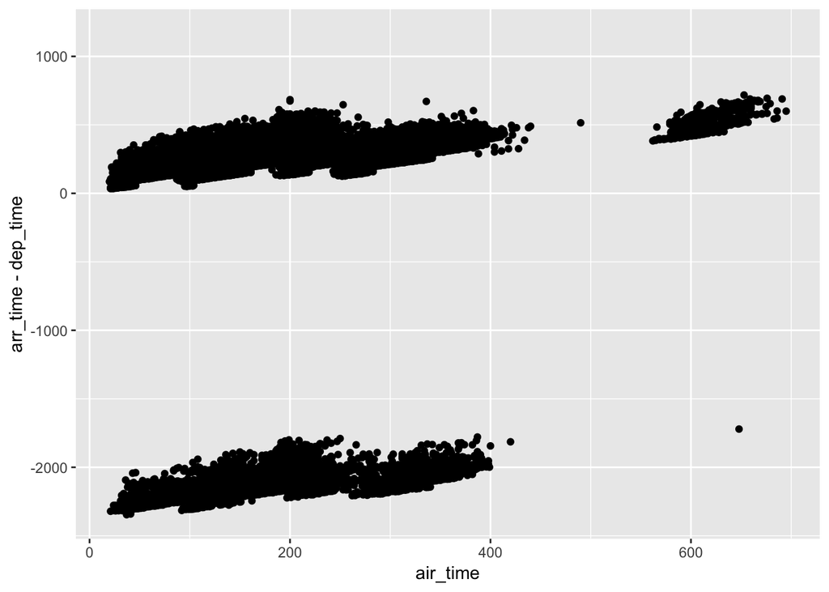

```r
ggplot(flights,aes(x=air_time,y=arr_time - dep_time)) +
  geom_point()
```

3. We would have to convert the data into minutes. I believe if the flights landing next day it would be harder to take those into account without a loop.

```r
mutate(flights,dep_time= ((dep_time %% 100) +(dep_time %/% 100)*60),arr_time= ((arr_time %% 100) + (arr_time %/% 100)*60))
```

```
## # A tibble: 336,776 x 19
##     year month   day dep_time sched_dep_time dep_delay arr_time
##    <int> <int> <int>    <dbl>          <int>     <dbl>    <dbl>
##  1  2013     1     1      317            515         2      510
##  2  2013     1     1      333            529         4      530
##  3  2013     1     1      342            540         2      563
##  4  2013     1     1      344            545        -1      604
##  5  2013     1     1      354            600        -6      492
##  6  2013     1     1      354            558        -4      460
##  7  2013     1     1      355            600        -5      553
##  8  2013     1     1      357            600        -3      429
##  9  2013     1     1      357            600        -3      518
## 10  2013     1     1      358            600        -2      473
## # ... with 336,766 more rows, and 12 more variables: sched_arr_time <int>,
## #   arr_delay <dbl>, carrier <chr>, flight <int>, tailnum <chr>,
## #   origin <chr>, dest <chr>, air_time <dbl>, distance <dbl>, hour <dbl>,
## #   minute <dbl>, time_hour <dttm>
```

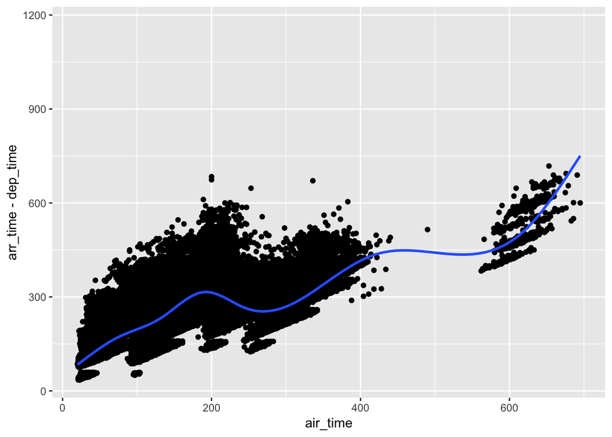

```r
#making sure for data of flights landed same day
flights1 <- filter(flights, arr_time > dep_time)
ggplot(flights1,aes(x=air_time,y=arr_time - dep_time)) +
  geom_point() +
geom_smooth(se=FALSE)
```

4.There will be error if air_time is not equal to the arr_time - dep_time or is too far off from air_time. It could be calculation errors. Time differences between zones or data inputting human errors.

I have set tollerance level as 100 minutes

```r
mutate(flights,dep_time = ((dep_time %% 100) + (dep_time %/% 100)*60),arr_time= ((arr_time %% 100) + (arr_time %/% 100)*60))
```

```
## # A tibble: 336,776 x 19
##     year month   day dep_time sched_dep_time dep_delay arr_time
##    <int> <int> <int>    <dbl>          <int>     <dbl>    <dbl>
##  1  2013     1     1      317            515         2      510
##  2  2013     1     1      333            529         4      530
##  3  2013     1     1      342            540         2      563
##  4  2013     1     1      344            545        -1      604
##  5  2013     1     1      354            600        -6      492
##  6  2013     1     1      354            558        -4      460
##  7  2013     1     1      355            600        -5      553
##  8  2013     1     1      357            600        -3      429
##  9  2013     1     1      357            600        -3      518
## 10  2013     1     1      358            600        -2      473
## # ... with 336,766 more rows, and 12 more variables: sched_arr_time <int>,
## #   arr_delay <dbl>, carrier <chr>, flight <int>, tailnum <chr>,
## #   origin <chr>, dest <chr>, air_time <dbl>, distance <dbl>, hour <dbl>,
## #   minute <dbl>, time_hour <dttm>
```

```r
flights$diff1 <- flights$dep_time - flights$arr_time
flights$diff2 <- flights$diff1 - flights$air_time
filter(flights, diff2 < 100)
```

```
## # A tibble: 316,810 x 21
##     year month   day dep_time sched_dep_time dep_delay arr_time
##    <int> <int> <int>    <int>          <int>     <dbl>    <int>
##  1  2013     1     1      517            515         2      830
##  2  2013     1     1      533            529         4      850
##  3  2013     1     1      542            540         2      923
##  4  2013     1     1      544            545        -1     1004
##  5  2013     1     1      554            600        -6      812
##  6  2013     1     1      554            558        -4      740
##  7  2013     1     1      555            600        -5      913
##  8  2013     1     1      557            600        -3      709
##  9  2013     1     1      557            600        -3      838
## 10  2013     1     1      558            600        -2      753
## # ... with 316,800 more rows, and 14 more variables: sched_arr_time <int>,
## #   arr_delay <dbl>, carrier <chr>, flight <int>, tailnum <chr>,
## #   origin <chr>, dest <chr>, air_time <dbl>, distance <dbl>, hour <dbl>,
## #   minute <dbl>, time_hour <dttm>, diff1 <int>, diff2 <dbl>
```

5. dep_time, sched_dep_time, and dep_delay should be related. I expect that in most data dep_delay should be equal to (sched_dep_time - dep_time). But there is a chance that delay was more than an hour so substraction won’t work as dep_delay is in minutes whereas dep_time is in HHMM number of rows of total data - 336776 number of rows that had a difference of 0 after the calculations and filtering - 228744

So still there is a lot of data rows that didn’t match.

```r
mutate(flights,dep_time = ((dep_time %% 100) + (dep_time %/% 100)*60),sched_dep_time= ((sched_dep_time %% 100) + (sched_dep_time %/% 100)*60))
```

```
## # A tibble: 336,776 x 21
##     year month   day dep_time sched_dep_time dep_delay arr_time
##    <int> <int> <int>    <dbl>          <dbl>     <dbl>    <int>
##  1  2013     1     1      317            315         2      830
##  2  2013     1     1      333            329         4      850
##  3  2013     1     1      342            340         2      923
##  4  2013     1     1      344            345        -1     1004
##  5  2013     1     1      354            360        -6      812
##  6  2013     1     1      354            358        -4      740
##  7  2013     1     1      355            360        -5      913
##  8  2013     1     1      357            360        -3      709
##  9  2013     1     1      357            360        -3      838
## 10  2013     1     1      358            360        -2      753
## # ... with 336,766 more rows, and 14 more variables: sched_arr_time <int>,
## #   arr_delay <dbl>, carrier <chr>, flight <int>, tailnum <chr>,
## #   origin <chr>, dest <chr>, air_time <dbl>, distance <dbl>, hour <dbl>,
## #   minute <dbl>, time_hour <dttm>, diff1 <int>, diff2 <dbl>
```

```r
flights$diffdelay <-flights$dep_time -  flights$sched_dep_time
flights$diff <- flights$diffdelay - flights$dep_delay
#now to check flights$diff == 0
filter(flights, diff == 0)
```

```
## # A tibble: 228,744 x 23
##     year month   day dep_time sched_dep_time dep_delay arr_time
##    <int> <int> <int>    <int>          <int>     <dbl>    <int>
##  1  2013     1     1      517            515         2      830
##  2  2013     1     1      533            529         4      850
##  3  2013     1     1      542            540         2      923
##  4  2013     1     1      544            545        -1     1004
##  5  2013     1     1      554            558        -4      740
##  6  2013     1     1      559            559         0      702
##  7  2013     1     1      600            600         0      851
##  8  2013     1     1      600            600         0      837
##  9  2013     1     1      601            600         1      844
## 10  2013     1     1      602            610        -8      812
## # ... with 228,734 more rows, and 16 more variables: sched_arr_time <int>,
## #   arr_delay <dbl>, carrier <chr>, flight <int>, tailnum <chr>,
## #   origin <chr>, dest <chr>, air_time <dbl>, distance <dbl>, hour <dbl>,
## #   minute <dbl>, time_hour <dttm>, diff1 <int>, diff2 <dbl>,
## #   diffdelay <int>, diff <dbl>
```

6. The 10 most delayed flights using a ranking function. Ties are not here in this data but can be handled by setting row_number(): equivalent to rank(ties.method = “first”)

```r
filter(flights, min_rank(desc(dep_delay))<11)
```

```
## # A tibble: 10 x 23
##     year month   day dep_time sched_dep_time dep_delay arr_time
##    <int> <int> <int>    <int>          <int>     <dbl>    <int>
##  1  2013     1     9      641            900      1301     1242
##  2  2013     1    10     1121           1635      1126     1239
##  3  2013    12     5      756           1700       896     1058
##  4  2013     3    17     2321            810       911      135
##  5  2013     4    10     1100           1900       960     1342
##  6  2013     6    15     1432           1935      1137     1607
##  7  2013     6    27      959           1900       899     1236
##  8  2013     7    22      845           1600      1005     1044
##  9  2013     7    22     2257            759       898      121
## 10  2013     9    20     1139           1845      1014     1457
## # ... with 16 more variables: sched_arr_time <int>, arr_delay <dbl>,
## #   carrier <chr>, flight <int>, tailnum <chr>, origin <chr>, dest <chr>,
## #   air_time <dbl>, distance <dbl>, hour <dbl>, minute <dbl>,
## #   time_hour <dttm>, diff1 <int>, diff2 <dbl>, diffdelay <int>,
## #   diff <dbl>
```

```r
top_n(flights, n=10, wt = dep_delay)
```

```
## # A tibble: 10 x 23
##     year month   day dep_time sched_dep_time dep_delay arr_time
##    <int> <int> <int>    <int>          <int>     <dbl>    <int>
##  1  2013     1     9      641            900      1301     1242
##  2  2013     1    10     1121           1635      1126     1239
##  3  2013    12     5      756           1700       896     1058
##  4  2013     3    17     2321            810       911      135
##  5  2013     4    10     1100           1900       960     1342
##  6  2013     6    15     1432           1935      1137     1607
##  7  2013     6    27      959           1900       899     1236
##  8  2013     7    22      845           1600      1005     1044
##  9  2013     7    22     2257            759       898      121
## 10  2013     9    20     1139           1845      1014     1457
## # ... with 16 more variables: sched_arr_time <int>, arr_delay <dbl>,
## #   carrier <chr>, flight <int>, tailnum <chr>, origin <chr>, dest <chr>,
## #   air_time <dbl>, distance <dbl>, hour <dbl>, minute <dbl>,
## #   time_hour <dttm>, diff1 <int>, diff2 <dbl>, diffdelay <int>,
## #   diff <dbl>
```

# 3 Public Sector Application

## 3.1 Download BTS data

```r
knitr::opts_knit$set(root.dir = '/Users/apple/Desktop/skills1' )
library(data.table)
file_names <- dir("/Users/apple/Desktop/skills1") #where you have your files


library(readr)
library(dplyr)
chi.flights = lapply(file_names, read_csv) %>% bind_rows()
```

## 3.2 Data Description

1. Tail number is the unique identifier for each flight as they are unique.
2. print, head, str, glimpse, View, summary are run below. print/head/str/glimpse are giving similar information. I would use the head/print to view the data.

List of non redundant methods a. head - Returns the first or last parts of a vector, matrix, table, data frame or function. Since head() and tail() are generic functions, they may also have been extended to other classes. b. View - Invoke a spreadsheet-style data viewer on a matrix-like R object. c. Summary - summary is a generic function used to produce result summaries of the results of various model fitting functions.

```r
print(chi.flights)

print(head(chi.flights))

str(chi.flights)

glimpse(chi.flights)

View(chi.flights)

summary(chi.flights)
```

## 3.3 Data Validation

```r
library(testthat)
test_that("we have the right number
of rows",expect_equal(nrow(chi.flights),675822))
```

Because of the conditions you put into the webform, all flights should be to or from Illinois airports. Let’s check this.

```r
library(testthat)
testforIL <- filter(chi.flights, ORIGIN_STATE_ABR == "IL" | DEST_STATE_ABR == "IL")
test_that("we have the right number
of rows",expect_equal(nrow(testforIL),675822))
```

```r
filter(chi.flights, DEST!= "MDW" & DEST!= "ORD")
```

6. Data is not matching for three highest volume airlines at ohare because data is old of 2016 and sometimes not all airlines are taken into account